# Assignment 2 - Regression

Marti Pardes Salom

## Introduction

In this second assignment of Data mining we will be using the Prestige dataframe that comes with the `car` package, with this data we will try to make regression model where icome will be the dependent variable. First of all we will import the library so we can take a look at what data contains Prestige.

```r
library(car)
prestige <- Prestige
summary(prestige)
```

```
##    education          income          women           prestige
##  Min.   : 6.380   Min.   :  611   Min.   : 0.000   Min.   :14.80
##  1st Qu.: 8.445   1st Qu.: 4106   1st Qu.: 3.592   1st Qu.:35.23
##  Median :10.540   Median : 5930   Median :13.600   Median :43.60
##  Mean   :10.738   Mean   : 6798   Mean   :28.979   Mean   :46.83
##  3rd Qu.:12.648   3rd Qu.: 8187   3rd Qu.:52.203   3rd Qu.:59.27
##  Max.   :15.970   Max.   :25879   Max.   :97.510   Max.   :87.20
##      census       type
##  Min.   :1113   bc  :44
##  1st Qu.:3120   prof:31
##  Median :5135   wc  :23
##  Mean   :5402   NA's: 4
##  3rd Qu.:8312
##  Max.   :9517
```

Lets plot all the data and see their correlation

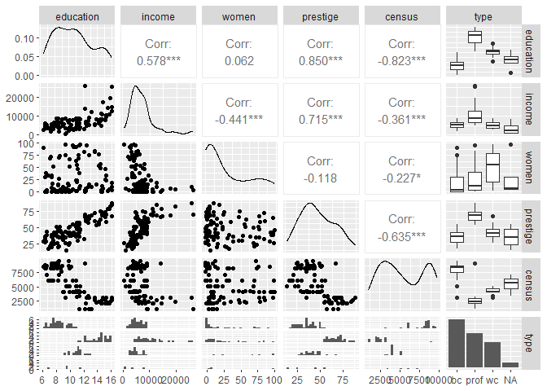

```r
library(ggplot2)
library(GGally)
ggpairs(data = prestige)
```

From the 6 columns we will focus only in 2: education, that contains the average education of occupational incumbents in years and income, the average income of incumbents in dolas dollars.

We will create a new dataframe with only this two columns to make our work easier

```r
df <- prestige[, c("education", "income")]
str(df)
```

```
## 'data.frame':    102 obs. of  2 variables:
##  $ education: num  13.1 12.3 12.8 11.4 14.6 ...
##  $ income   : int  12351 25879 9271 8865 8403 11030 8258 14163 11377 11023 ...
```

We can observ that the education columns is of type Number(double) that makes sense with what we just researched, and the income is of type Int.

The last thing we need to do before doing the data analysis is to check if the columns have any NANs.

```r
columns_with_nan <- colSums(is.na(df))
columns_with_nan
```

```
## education    income
##         0         0
```

As we can observe the data don’t have any missing values that we need to take care of.

## Data Analysis

Now that we have a ready dataframe we are going to take more indeepth look at the data, how is their distribution, how much are they correlated, there are any otliers? etc

First of all we will draw a histogram for income and a boxplot for education.

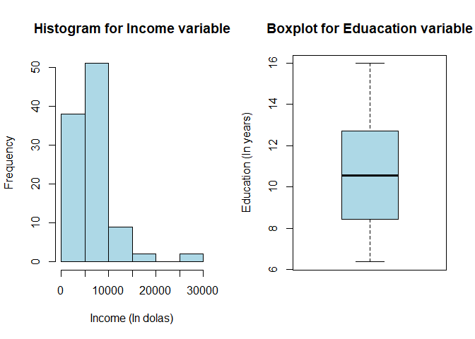

```r
par(mfrow = c(1, 2))

hist(df$income, main = "Histogram for Income variable", xlab = "Income (In dolas)", col = "lightblue")
boxplot(df$education, main = "Boxplot for Eduacation variable", ylab = "Education (In years)", col = "lightblue")
```

To deal with the outliers we are going to use the 1st and 3rd quartil to calculate the Interquartile Range (IQR) and then we will calculate all the points above and under 1.5 * IQR.

```r
quantiles = quantile(df$income)
q1 <- quantiles[2]
q3 <- quantiles[4]

iqr = q3 - q1
lower_bound = q1 - 1.5 * iqr
upper_bound = q3 + 1.5 * iqr

outliers <- df$income[df$income < lower_bound | df$income > upper_bound]
df[df$income < lower_bound | df$income > upper_bound, ]
```

```
##                          education income
## general.managers             12.26  25879
## lawyers                      15.77  19263
## physicians                   15.96  25308
## veterinarians                15.94  14558
## osteopaths.chiropractors     14.71  17498
```

As we can observe here we have all the data that fit the criteria given, now we will plot again and mark the outliers with a red color.

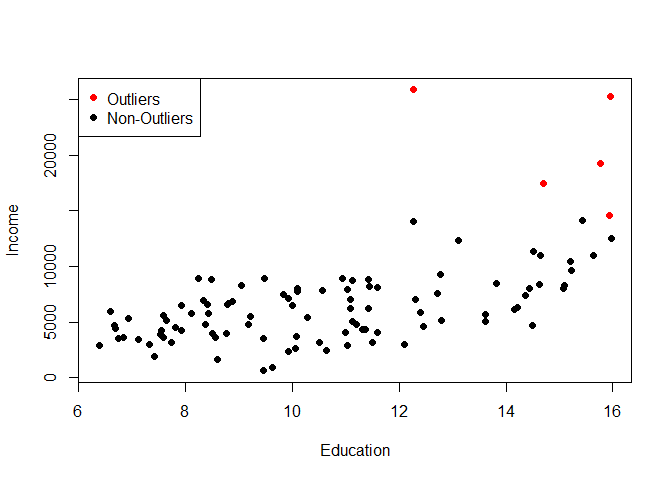

```r
plot(df$education, df$income,
     xlab="Education", ylab="Income", col=ifelse(df$income < lower_bound | df$income > upper_bound, "red", "black"), pch=16)

legend("topleft", legend=c("Outliers", "Non-Outliers"), col=c("red", "black"), pch=16)
```

It is evident from our analysis that certain data points deviate significantly from the expected linearity of the data and knowing that we will be doing a linear regression model, that’s very afected by outliers we will be removing them from our data.

```r
df <- df[!(df$income < lower_bound | df$income > upper_bound), ]
```

To wrap up the data exploration process, we aim to gain insights into the overall distribution of the dataset. To achieve this, a scatter plot will be generated using the GGally library. A scatter plot is a visual representation that allows us to observe the relationships and patterns between two variables simultaneously. In our case, it will provide a graphical depiction of how the data points are distributed concerning both income and education.

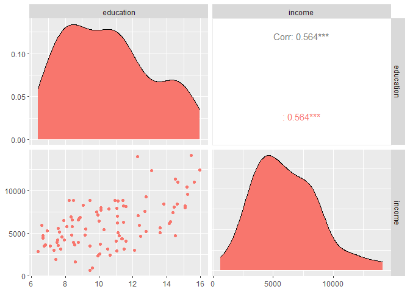

```r
ggpairs(data = df, mapping = aes(color = ""))
```

## Regression Models

Now that we have a good feel about the data and we address our possible problems we will make a linear regression , to do this we will us the `lm` function and to measure how good it’s we will look at the r-squared, a high R-squared value, approaching 1, signifies a stronger fit of the model to the data, reinforcing the reliability of our predictions.

Furthermore, we’ll examine the p-values associated with each coefficient in the regression model. A low p-value, commonly below 0.05, indicates the statistical significance of a predictor variable.

```r
regression <- lm( income ~ education, data=df)
print(summary(regression))
```

```
##
## Call:
## lm(formula = income ~ education, data = df)
##
## Residuals:
##     Min      1Q  Median      3Q     Max
## -4843.4 -1757.3  -103.6  1621.5  6891.8
##
## Coefficients:
##             Estimate Std. Error t value Pr(>|t|)
## (Intercept)  -220.78     977.10  -0.226    0.822
## education     599.91      90.17   6.653 1.83e-09 ***
## ---
## Signif. codes:  0 '***' 0.001 '**' 0.01 '*' 0.05 '.' 0.1 ' ' 1
##
## Residual standard error: 2298 on 95 degrees of freedom
## Multiple R-squared:  0.3178, Adjusted R-squared:  0.3106
## F-statistic: 44.26 on 1 and 95 DF,  p-value: 1.827e-09
```

Looking at the summary of the regression we can see that our p-value has a value of 1.83e-09, way lower from 0.05, the R-saqured value is 0.3178, not very good but it’s a good starting point, lets show the regression line above our scatterplot to see the trend.

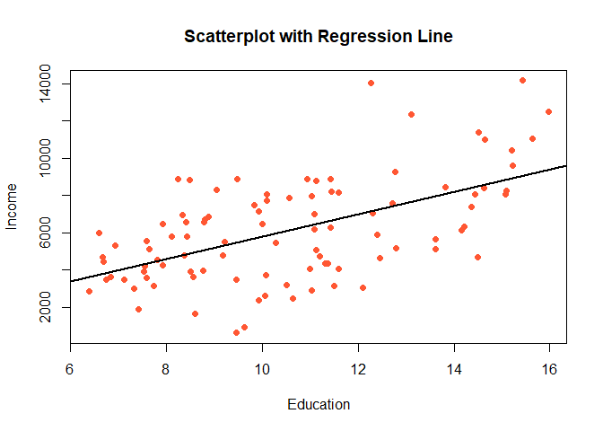

```r
plot(df$education, df$income,
     main="Scatterplot with Regression Line",
     xlab="Education", ylab="Income", col="#FF5733", pch=16)
abline(regression, col="black", lwd=2)
```

We can clearly see a positive trend where our data seems to follow it quite well. To see if the assumption of the regression holds we need to look at the residuals, the residuals are the differences between the observed values and the values predicted by the regression model, to asure the assumption holds we need to observe if the plot follows this criteria:

- Linearity
- Constant Variance
- Independence
- Normality

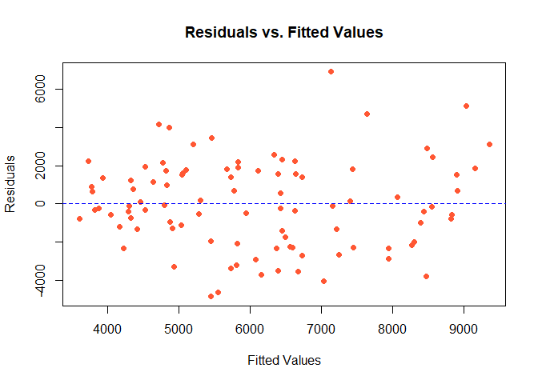

```r
plot(predict(regression), residuals(regression),
     main = "Residuals vs. Fitted Values",
     xlab = "Fitted Values", ylab = "Residuals",
     col = "#FF5733", pch = 16)

abline(h = 0, col = "blue", lty = 2)
```

As we can see the data follows all the previous points, making it a valid dataset to apply the regression. Now in order to try to improve the regression we will be doing a polynomial regression model, we will try degree 2 and degree 3 and see how our r-square improves.

```r
poly_model <- lm(income ~ poly(education, 2), data = df)
summary(poly_model)
```

```
##
## Call:
## lm(formula = income ~ poly(education, 2), data = df)
##
## Residuals:
##     Min      1Q  Median      3Q     Max
## -4525.5 -1647.6   -77.4  1770.6  7261.8
##
## Coefficients:
##                     Estimate Std. Error t value Pr(>|t|)
## (Intercept)           6091.5      229.8  26.509  < 2e-16 ***
## poly(education, 2)1  15290.4     2263.2   6.756 1.17e-09 ***
## poly(education, 2)2   4512.6     2263.2   1.994   0.0491 *
## ---
## Signif. codes:  0 '***' 0.001 '**' 0.01 '*' 0.05 '.' 0.1 ' ' 1
##
## Residual standard error: 2263 on 94 degrees of freedom
## Multiple R-squared:  0.3455, Adjusted R-squared:  0.3316
## F-statistic: 24.81 on 2 and 94 DF,  p-value: 2.226e-09
```

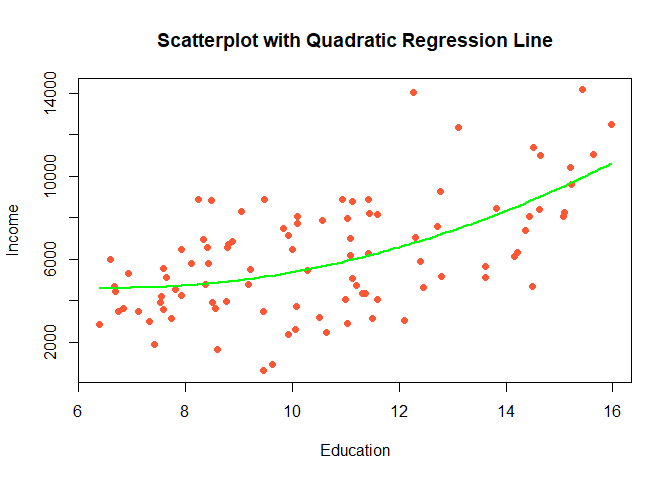

```r
plot(df$education, df$income,
     main="Scatterplot with Quadratic Regression Line",
     xlab="Education", ylab="Income", col="#FF5733", pch=16)

x_seq <- seq(min(df$education), max(df$education), length.out = 100)
y_pred <- predict(poly_model, newdata = data.frame(education = x_seq, education2 = x_seq^2))
lines(x_seq, y_pred, col="green", lwd=2)
```

```r
cubic_model <- lm(income ~ poly(education, 3), data = df)
summary(cubic_model)
```

```
##
## Call:
## lm(formula = income ~ poly(education, 3), data = df)
##
## Residuals:
##     Min      1Q  Median      3Q     Max
## -4873.2 -1595.2  -310.5  1533.6  7692.8
##
## Coefficients:
##                     Estimate Std. Error t value Pr(>|t|)
## (Intercept)           6091.5      227.8  26.737  < 2e-16 ***
## poly(education, 3)1  15290.4     2243.9   6.814 9.29e-10 ***
## poly(education, 3)2   4512.6     2243.9   2.011   0.0472 *
## poly(education, 3)3   3630.8     2243.9   1.618   0.1090
## ---
## Signif. codes:  0 '***' 0.001 '**' 0.01 '*' 0.05 '.' 0.1 ' ' 1
##
## Residual standard error: 2244 on 93 degrees of freedom
## Multiple R-squared:  0.3634, Adjusted R-squared:  0.3429
## F-statistic:  17.7 on 3 and 93 DF,  p-value: 3.603e-09
```

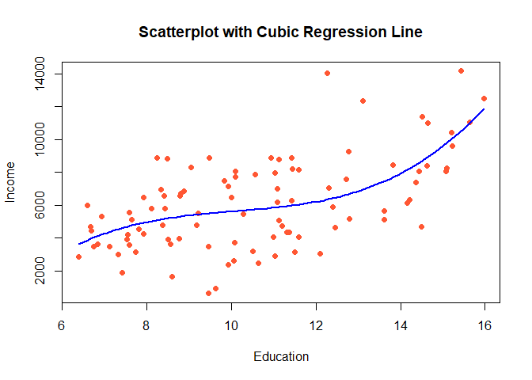

```r
plot(df$education, df$income,
     main="Scatterplot with Cubic Regression Line",
     xlab="Education", ylab="Income", col="#FF5733", pch=16)

x_seq_3 <- seq(min(df$education), max(df$education), length.out = 100)
y_pred_3 <- predict(cubic_model, newdata = data.frame(education = x_seq))
lines(x_seq_3, y_pred_3, col="blue", lwd=2)
```

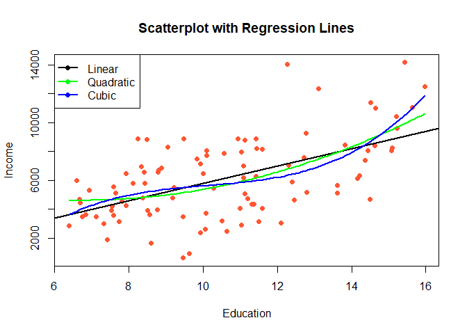

```r
plot(df$education, df$income,
     main="Scatterplot with Regression Lines",
     xlab="Education", ylab="Income", col="#FF5733", pch=16)
abline(regression, col="black", lwd=2)
lines(x_seq, y_pred, col="green", lwd=2)
lines(x_seq_3, y_pred_3, col="blue", lwd=2)
legend("topleft", legend=c("Linear", "Quadratic", "Cubic"),
       col=c("black", "green", "blue"), lwd=2, pch=16)
```

As we can clearly observe in the scatter, the bigger the degree the much fitted is the data, in polynomial regression, the degree represents the order of the polynomial, and each increase in degree introduces additional flexibility to the model. As we can imagine the rsquare of the models with degree 3 will be higher, lets print the results:

```r
cat("Linear ->", summary(regression)$r.squared, "\n")
```

```
## Linear -> 0.3178226
```

```r
cat("Quadratic ->", summary(poly_model)$r.squared, "\n")
```

```
## Quadratic -> 0.3455052
```

```r
cat("Cubic ->", summary(cubic_model)$r.squared, "\n")
```

```
## Cubic -> 0.363426
```

As we tough, the cubic model (degree 3) has a higher R-squared value compared to other models.

## Data transformations

Finally we will doing two transformations to our data to see if we can get better results, first we will apply the logarithmic function and the the square root, finally we will a create a new regression model and see how out r-square value changes.

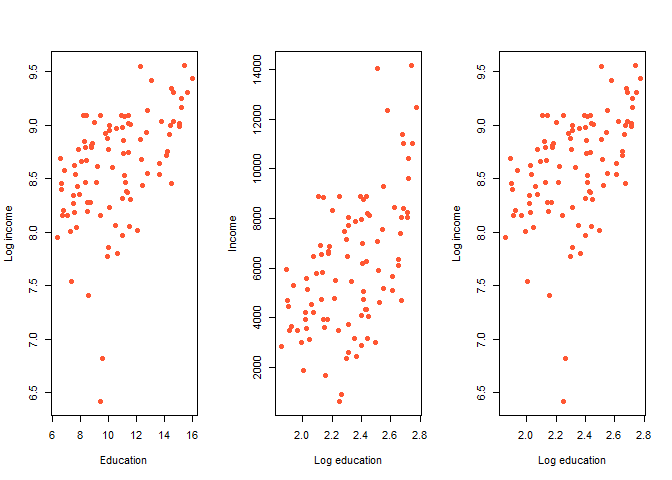

```r
df$log_income <- log(df$income)
df$log_education <- log(df$education)

par(mfrow = c(1, 3))

plot(df$education, df$log_income,
     xlab="Education", ylab="Log income", col="#FF5733", pch=16)

plot(df$log_education, df$income,
     xlab="Log education", ylab="Income", col="#FF5733", pch=16)

plot(df$log_education, df$log_income,
     xlab="Log education", ylab="Log income", col="#FF5733", pch=16)
```

As we can observe the most linear plot is the one that we apply log to both x (education) and y (income), as we previously said we will make a linear regression.

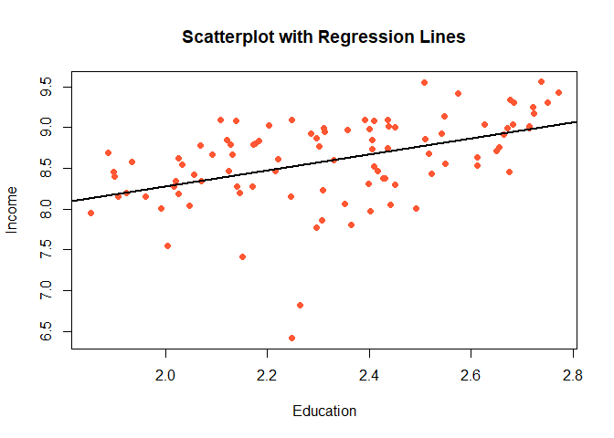

```r
loglog <- lm( log_income ~ log_education, data=df )
plot(df$log_education, df$log_income,
     main="Scatterplot with Regression Lines",
     xlab="Education", ylab="Income", col="#FF5733", pch=16)
abline(loglog, col="black", lwd=2)
```

```r
summary(loglog)
```

```
##
## Call:
## lm(formula = log_income ~ log_education, data = df)
##
## Residuals:
##     Min      1Q  Median      3Q     Max
## -2.1071 -0.2303  0.0636  0.3404  0.7736
##
## Coefficients:
##               Estimate Std. Error t value Pr(>|t|)
## (Intercept)     6.3333     0.4567  13.868  < 2e-16 ***
## log_education   0.9741     0.1955   4.983  2.8e-06 ***
## ---
## Signif. codes:  0 '***' 0.001 '**' 0.01 '*' 0.05 '.' 0.1 ' ' 1
##
## Residual standard error: 0.4743 on 95 degrees of freedom
## Multiple R-squared:  0.2072, Adjusted R-squared:  0.1989
## F-statistic: 24.83 on 1 and 95 DF,  p-value: 2.803e-06
```

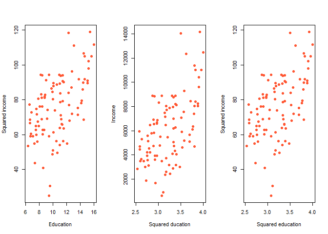

```r
df$sqr_income <- sqrt(df$income)
df$sqr_education <- sqrt(df$education)

par(mfrow = c(1, 3))

plot(df$education, df$sqr_income,
     xlab="Education", ylab="Squared income", col="#FF5733", pch=16)

plot(df$sqr_education, df$income,
     xlab="Squared ducation", ylab="Income", col="#FF5733", pch=16)

plot(df$sqr_education, df$sqr_income,
     xlab="Squared education", ylab="Squared income", col="#FF5733", pch=16)
```

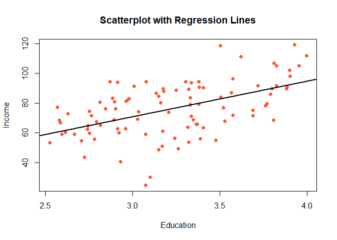

```r
sqrsqr <- lm( sqr_income ~ sqr_education, data=df )
plot(df$sqr_education, df$sqr_income,
     main="Scatterplot with Regression Lines",
     xlab="Education", ylab="Income", col="#FF5733", pch=16)
abline(sqrsqr, col="black", lwd=2)
```

```r
summary(sqrsqr)
```

```
##
## Call:
## lm(formula = sqr_income ~ sqr_education, data = df)
##
## Residuals:
##     Min      1Q  Median      3Q     Max
## -47.799  -9.699   0.776  11.559  35.760
##
## Coefficients:
##               Estimate Std. Error t value Pr(>|t|)
## (Intercept)    -0.7759    12.8650  -0.060    0.952
## sqr_education  23.8298     3.9661   6.008 3.44e-08 ***
## ---
## Signif. codes:  0 '***' 0.001 '**' 0.01 '*' 0.05 '.' 0.1 ' ' 1
##
## Residual standard error: 15.49 on 95 degrees of freedom
## Multiple R-squared:  0.2754, Adjusted R-squared:  0.2677
## F-statistic:  36.1 on 1 and 95 DF,  p-value: 3.439e-08
```